# Puppy Raiser Questionnaire vs Outcome (Success, Fail)

Marinara Marcato

# 1 Introduction

In order to objectively evaluate trainee guide dogs personality, their puppy raisers filled out the standardised questionnaire Canine Behavioural Assessement & Research Questionnaire (C-BARQ) around the time they were due to start formal training. This document shows the data analysis carried out to investigate the association between ratings given by the puppy raisers and the dog’s training outcome. Statistical methods will be used to test the hypothesis that there is a relationship between personality ratings and training outcome (Success, Fail).

# 2 Data Exploration

Importing data and converting variables to adequate data types.

## 2.1 Demographics

The number of dogs in the Puppy Raiser Questionnaire dataset. Selection criteria: dogs who successed training (assistance and guide dogs) and dogs withdrawn for behavioural reasons.

```
## Number of dogs: 63
```

```
## Training Outcome:
```

```
##
##    Fail Success
##      11      52
```

Analysing categorical demographic data: Sex, Breed. There was only one German Shepherd and Golden Doodle dogs in the sample, their breeds were relabeled as “Other” for the data analysis.

```
## [1] "Original classes"
```

```
##
## GRxPoodle        GS        LR       LRx     LRxGR
##         1         1        25         9        27
```

```
## [1] "Processed classes"
```

```
##
## Other    LR LRxGR
##     2    25    36
```

```
##
##  F  M
## 30 33
```

Analysing age at arrival to the training centre and age at assessment when the questionnaire was completed:

```
## Age at Arrival: Mean 15.27 Standard Deviation 2.75
```

```
## Age at Assessment: Mean 16.13 Standard Deviation 3.4
```

Calculate statistics of duration of training for the dogs that were withdrawn from training.

```
## [1] "Duration of Training in weeks"
```

```
##     Duration
##  Min.   : 1.143
##  1st Qu.: 9.786
##  Median :13.000
##  Mean   :13.935
##  3rd Qu.:15.214
##  Max.   :31.143
```

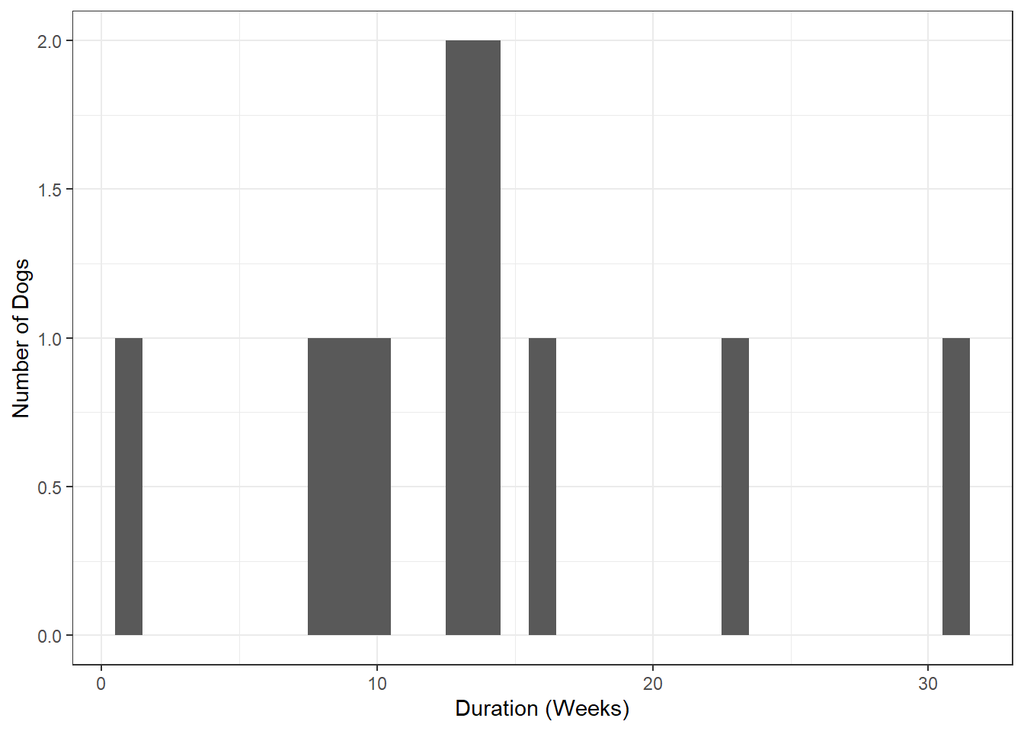

```
## Image saved at results/prq/duration-histogram.png
```

## 2.2 Descriptive Statistics

The C-BARQ contains 100 items which were scored by the Puppy Raisers in a scale from ‘Never’, ‘Seldom’, ‘Sometimes’, ‘Usually’, ‘Always’ and encoded in a scale from 0 to 4. Out of the 100 items, 78 items are used to calculate 14 factors and the remaining 22 items are myscellaneous. The questionnaire data are kept as numeric, rather than being converted to factors, so the information about the ordering is kept. The descriptive statistics of the questionnaire data shown below are calculated and saved as a csv.  
Missing data is also analysed.

```
## [1] "Items"
```

```
##   [1] "I_01.When.off.the.leash.returns.immediately.when.called"
##   [2] "I_02.Obeys.the.sit.command.immediately"
##   [3] "I_03.Obeys.the.stay.command.immediately"
##   [4] "I_04.Seems.to.attend.or.listen.closely.to.everything.you.say.or.do"
##   [5] "I_05.Slow.to.respond.to.correction.or.punishment.thickskinned"
##   [6] "I_06.Slow.to.learn.new.tricks.or.tasks"
##   [7] "I_07.Easily.distracted.by.interesting.sights.sounds.or.smells"
##   [8] "I_08.Will.fetch.or.attempt.to.fetch.sticks.balls.or.objects"
##   [9] "I_09.When.verbally.corrected.or.punished.scolded.shouted.at.etc.by.you.or.a.household.member"
##  [10] "I_10.When.approached.directly.by.an.unfamiliar.adult.while.being.walked.on.a.leash"
##  [11] "I_11.When.approached.directly.by.an.unfamiliar.child.while.being.walked.on.a.leash"
##  [12] "I_12.Toward.unfamiliar.persons.approaching.the.dog.while.she.is.in.your.car.at.the.gas.station.for.example"
##  [13] "I_13.When.toys.bones.or.other.objects.are.taken.away.by.a.household.member"
##  [14] "I_14.When.bathed.or.groomed.by.a.household.member"
##  [15] "I_15.When.an.unfamiliar.person.approaches.you.or.another.member.of.your.family.at.home"
```

[output cut: 85 more lines]

```
## [1] "Factors, Demographic and Outcome"
```

```
## 'data.frame':    63 obs. of  17 variables:
##  $ F_01.Trainability                : num  3 3 3.12 3.62 2.62 ...
##  $ F_02.Stranger.directed.aggression: num  0.1 0 0.2 0 0 0 0 0.1 0.2 0 ...
##  $ F_03.Owner.directed.aggression   : num  0 0 0 0 0 0 0 0 0 0 ...
##  $ F_04.Dog.rivalry                 : num  NA 0 0.25 0 NA 0 0 0 0.5 0 ...
##  $ F_05.Stranger.directed.fear      : num  0 0 0.25 0 0 0 0 0 0 0 ...
##  $ F_06.Nonsocial.fear              : num  0 0 0.833 0.333 0 ...
##  $ F_07.Dog.directed.aggression     : num  0 0 0 0 1 0 0 0 0 0 ...
##  $ F_08.Dog.directed.fear           : num  0.5 0 0.25 0.25 0 ...
##  $ F_09.Touch.sensitivity           : num  0.25 0 1.25 0 0 ...
##  $ F_10.Separation.related.behaviour: num  0.125 0.875 0.75 0 0.625 0 0 0.75 1 0.375 ...
##  $ F_11.Excitability                : num  2 0.6 2.167 0.833 0.833 ...
##  $ F_12.Attachment.attention.seeking: num  1.83 2 2.83 0.5 1.6 ...
##  $ F_13.Chasing                     : num  1.25 0.667 1.75 2.25 1.333 ...
##  $ F_14.Energy                      : num  3 2 2 0 1.5 0 2 4 1 1.5 ...
##  $ Sex                              : Factor w/ 2 levels "F","M": 1 2 2 2 2 2 2 1 2 1 ...
##  $ Breed                            : Factor w/ 3 levels "Other","LR","LRxGR": 3 3 2 3 3 3 3 3 3 3 ...
##  $ Outcome                          : Factor w/ 2 levels "Fail","Success": 2 2 2 2 2 2 2 1 2 2 ...
```

```
## [1] "Features sorted by number of missing rows"
```

```
##                                                                                                                                          NA.s
## I_49.When.having.nails.clipped.by.a.household.member                                                                                       28
## I_76.Chases.or.would.chase.squirrels.rabbits.and.other.small.animals.given.the.opportunity                                                 18
## I_34.When.approached.while.eating.by.another.familiar.household.dog.NA.if.no.other.dogs                                                    12
## I_33.When.approached.at.a.favourite.resting.or.sleeping.place.by.another.familiar.household.dog.NA.if.no.other.dogs                        11
## F_04.Dog.rivalry                                                                                                                           11
## I_32.Towards.another.familiar.dog.in.your.household.NA.if.no.other.dogs                                                                    10
## I_35.When.approached.while.playing.with.or.chewing.a.favourite.toy.bone.object.etc.by.another.familiar.household.dog.NA.if.no.other.dogs   10
## I_74.Chases.or.would.chase.cats.given.the.opportunity                                                                                       7
## I_93.Stares.intently.at.nothing.visible                                                                                                     7
## I_100.Displays.other.bizarre.strange.or.repetitive.behaviours                                                                               7
## I_05.Slow.to.respond.to.correction.or.punishment.thickskinned                                                                               6
## I_09.When.verbally.corrected.or.punished.scolded.shouted.at.etc.by.you.or.a.household.member                                                6
## I_77.Escapes.or.would.escape.from.home.or.yard.given.the.chance                                                                             6
## I_96.Chases.or.follows.shadows.light.spots.etc                                                                                              5
## I_52.When.unfamiliar.dogs.visit.your.home                                                                                                   4
## I_94.Snaps.at.invisible.flies                                                                                                               4
## F_13.Chasing                                                                                                                                4
## I_08.Will.fetch.or.attempt.to.fetch.sticks.balls.or.objects                                                                                 3
```

```
## dataframe saved to  results/prq/descriptive-statistics.csv
```

## 2.3 Feature Selection

### 2.3.1 Criteria 1, 2 and 3: Univariate Logistic Regression

Logistic regression was used to investigate whether there was a statistically significant difference between the behaviours reported by Puppy Raisers and the Training Outcome of the dogs. C-BARQ Correlation with Training Outcome.

```
##                                                         Length Class Mode
## I_01.When.off.the.leash.returns.immediately.when.called 30     glm   list
```

```
## $Breed
##
## Call:  glm(formula = Outcome ~ x, family = binomial(link = logit), data = data,
##     na.action = na.exclude)
##
## Coefficients:
## (Intercept)          xLR       xLRxGR
##   4.690e-15   -1.153e+00   -2.079e+00
##
## Degrees of Freedom: 62 Total (i.e. Null);  60 Residual
## Null Deviance:       58.35
## Residual Deviance: 55.44     AIC: 61.44
```

```
## Difference between Other and LR:      0.4390785   -> not significant
```

```
## Difference between Other and LRxGR:   0.1685832   -> not significant
```

```
## [1] "Columns 9,10,13,17,30,37 are CONSTANT, that's why they p_values don't make sense"
```

```
## [1] -4.443853 -4.680547 -4.680547 -4.680547 -4.680547 -4.614145
```

```
## dataframe saved to  results/prq/univariate-logistic-regression.csv
```

Converting logistic regression result to odds ratio and confidence intervals.

```
## dataframe saved to  results/prq/lr-or-ci.csv
```

Analysing p-values and deviance. Analysing deviance of full model compared to the null model. Reduction in deviance must be significant (chi-squared test) for the model to be considered a good fit.

```
## [1] "Number of features considering each level of significance using Logistic Regression p-value & difference in deviance test"
```

```
## significant_0.05  significant_0.1  significant_0.2
##               29               43               56
```

```
## Number of features whose univariate models resulted in a significant difference in deviance:  65
```

Feature selection based on the univariate logistic regression p-value and deviance analysis. This reduced feature set contains all factors and only items that were NOT included in the calculation of statistically significant factor with p<0.05 (i.e. Items 1,27 an 75 and some myscellaneous items 77-90, 93-100).

```
##                                                                                                                estimate_1
## I_01.When.off.the.leash.returns.immediately.when.called                                                        -1.1150352
## I_26.Toward.unfamiliar.dogs.visiting.your.home                                                                  1.3095162
## I_27.Toward.cats.squirrels.or.other.small.animals.entering.your.yard                                            1.0045766
## I_29.When.barked.growled.or.lunged.at.by.another.unfamiliar.dog                                                 1.0702839
## I_38.In.response.to.sudden.or.loud.noises.eg.vacuum.cleaner.car.backfire.road.drills.objects.being.dropped.etc  1.0310037
## I_45.When.approached.directly.by.an.unfamiliar.dog.of.the.same.or.larger.size                                   0.8342065
## I_53.When.barked.growled.or.lunged.at.by.an.unfamiliar.dog                                                      0.7036893
## I_54.Shaking.shivering.or.trembling                                                                             1.5103679
## I_56.Restlessness.agitation.pacing                                                                              0.8091538
## I_57.Whining                                                                                                    0.7896828
## I_61.Barking                                                                                                    0.6577485
## I_62.When.you.or.other.members.of.the.household.come.home.after.a.brief.absence                                 1.0421387
## I_63.When.playing.with.you.or.other.members.of.your.household                                                   0.8759231
## I_64.When.doorbell.rings                                                                                        0.7505748
## I_65.Just.before.being.taken.for.a.walk                                                                         0.7292660
## I_66.Just.before.being.taken.on.a.car.trip                                                                      0.6431185
## I_75.Chases.or.would.chase.birds.given.the.opportunity                                                          0.6072653
## I_77.Escapes.or.would.escape.from.home.or.yard.given.the.chance                                                 1.0511635
## I_82.Begs.persistently.for.food.when.people.are.eating                                                          0.6821596
## I_85.Pulls.excessively.hard.when.on.the.leash                                                                   0.8210438
## I_90.Hyperactive.restless.has.trouble.settling.down                                                             0.8709902
## I_93.Stares.intently.at.nothing.visible                                                                         1.0302983
## I_99.Licks.people.or.objects.excessively                                                                        0.8405546
## F_02.Stranger.directed.aggression                                                                               5.7418280
## F_06.Nonsocial.fear                                                                                             2.5111001
## F_07.Dog.directed.aggression                                                                                    1.5768130
## F_08.Dog.directed.fear                                                                                          0.9589780
## F_10.Separation.related.behaviour                                                                               2.8473775
## F_11.Excitability                                                                                               1.2547291
##                                                                                                                  p_value_1
## I_01.When.off.the.leash.returns.immediately.when.called                                                        0.014679143
## I_26.Toward.unfamiliar.dogs.visiting.your.home                                                                 0.011899275
## I_27.Toward.cats.squirrels.or.other.small.animals.entering.your.yard                                           0.039541433
## I_29.When.barked.growled.or.lunged.at.by.another.unfamiliar.dog                                                0.012038869
## I_38.In.response.to.sudden.or.loud.noises.eg.vacuum.cleaner.car.backfire.road.drills.objects.being.dropped.etc 0.025678016
## I_45.When.approached.directly.by.an.unfamiliar.dog.of.the.same.or.larger.size                                  0.030825643
## I_53.When.barked.growled.or.lunged.at.by.an.unfamiliar.dog                                                     0.023445053
## I_54.Shaking.shivering.or.trembling                                                                            0.049351101
## I_56.Restlessness.agitation.pacing                                                                             0.034880473
```

[output cut: 20 more lines]

```
## [1] "All features with level of significance < 0.05 using Univariate Logistic Regression p-value test"
```

```
## Full Feature Set with p<0.05 and reduction in deviance    63 30
```

```
## [1] "Keeping items 1, 27, 75 and anything between 77-90 and 93-100"
```

```
## Reduced Feature Set with p<0.05   63 16
```

```
##  [1] "I_01.When.off.the.leash.returns.immediately.when.called"
##  [2] "I_26.Toward.unfamiliar.dogs.visiting.your.home"
##  [3] "I_27.Toward.cats.squirrels.or.other.small.animals.entering.your.yard"
##  [4] "I_29.When.barked.growled.or.lunged.at.by.another.unfamiliar.dog"
##  [5] "I_38.In.response.to.sudden.or.loud.noises.eg.vacuum.cleaner.car.backfire.road.drills.objects.being.dropped.etc"
##  [6] "I_45.When.approached.directly.by.an.unfamiliar.dog.of.the.same.or.larger.size"
##  [7] "I_53.When.barked.growled.or.lunged.at.by.an.unfamiliar.dog"
##  [8] "I_54.Shaking.shivering.or.trembling"
##  [9] "I_56.Restlessness.agitation.pacing"
## [10] "I_57.Whining"
## [11] "I_61.Barking"
## [12] "I_62.When.you.or.other.members.of.the.household.come.home.after.a.brief.absence"
## [13] "I_63.When.playing.with.you.or.other.members.of.your.household"
## [14] "I_64.When.doorbell.rings"
## [15] "I_65.Just.before.being.taken.for.a.walk"
## [16] "I_66.Just.before.being.taken.on.a.car.trip"
## [17] "I_75.Chases.or.would.chase.birds.given.the.opportunity"
## [18] "I_77.Escapes.or.would.escape.from.home.or.yard.given.the.chance"
## [19] "I_82.Begs.persistently.for.food.when.people.are.eating"
## [20] "I_85.Pulls.excessively.hard.when.on.the.leash"
## [21] "I_90.Hyperactive.restless.has.trouble.settling.down"
## [22] "I_93.Stares.intently.at.nothing.visible"
## [23] "I_99.Licks.people.or.objects.excessively"
## [24] "F_02.Stranger.directed.aggression"
## [25] "F_06.Nonsocial.fear"
## [26] "F_07.Dog.directed.aggression"
## [27] "F_08.Dog.directed.fear"
## [28] "F_10.Separation.related.behaviour"
## [29] "F_11.Excitability"
## [30] "Outcome"
```

### 2.3.2 Criterion 4: Missing Data

PRQ, missing values per column and per row. Removing features with more than 5% missing data (i.e. I_77, I_93).

```
##              I_01.When.off.the.leash.returns.immediately.when.called
##                                                                    0
## I_27.Toward.cats.squirrels.or.other.small.animals.entering.your.yard
##                                                                    2
##               I_75.Chases.or.would.chase.birds.given.the.opportunity
##                                                                    1
##      I_77.Escapes.or.would.escape.from.home.or.yard.given.the.chance
##                                                                    6
##               I_82.Begs.persistently.for.food.when.people.are.eating
##                                                                    1
##                        I_85.Pulls.excessively.hard.when.on.the.leash
##                                                                    1
##                  I_90.Hyperactive.restless.has.trouble.settling.down
##                                                                    1
##                              I_93.Stares.intently.at.nothing.visible
##                                                                    7
##                             I_99.Licks.people.or.objects.excessively
##                                                                    3
##                                    F_02.Stranger.directed.aggression
##                                                                    0
##                                                  F_06.Nonsocial.fear
##                                                                    0
##                                         F_07.Dog.directed.aggression
##                                                                    0
##                                               F_08.Dog.directed.fear
##                                                                    0
##                                    F_10.Separation.related.behaviour
##                                                                    1
##                                                    F_11.Excitability
##                                                                    0
##                                                              Outcome
##                                                                    0
```

```
## dataframe saved to  results/prq/missing.csv
```

[output not shown]

```
## Reduced Feature Set with p<0.05 and < 5% missing data     63 14
```

### 2.3.3 Criterion 5: Correlation

Removing features with more than 0.75 correlation (i.e. F_07)

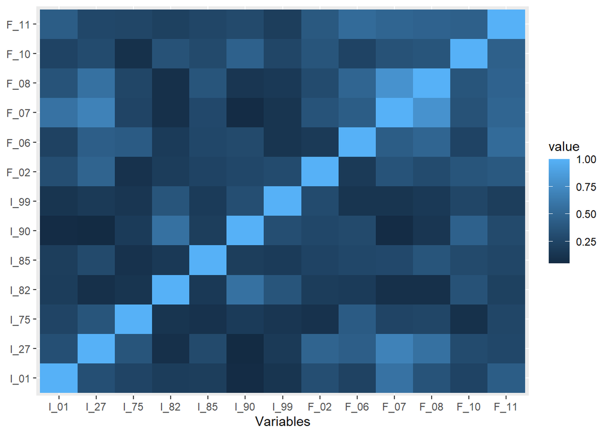

```
## Image saved at results/prq/correlation.png
```

```
## Highly correlated variable to be removed F_07
```

```
## Reduced Feature Set with p<0.05 and < 5% missing data and <75% correlated     63 13
```

## 2.4 Visualization

Plotting the items and factors that will be used for modelling.

```
## Image saved at results/prq/I_01-When-off-the-leash-returns-immediately-when-called.png
```

```
## Image saved at results/prq/I_27-Toward-cats-squirrels-or-other-small-animals-entering-your-yard.png
```

```
## Image saved at results/prq/I_75-Chases-or-would-chase-birds-given-the-opportunity.png
```

```
## Image saved at results/prq/I_82-Begs-persistently-for-food-when-people-are-eating.png
```

```
## Image saved at results/prq/I_85-Pulls-excessively-hard-when-on-the-leash.png
```

```
## Image saved at results/prq/I_90-Hyperactive-restless-has-trouble-settling-down.png
```

```
## Image saved at results/prq/I_99-Licks-people-or-objects-excessively.png
```

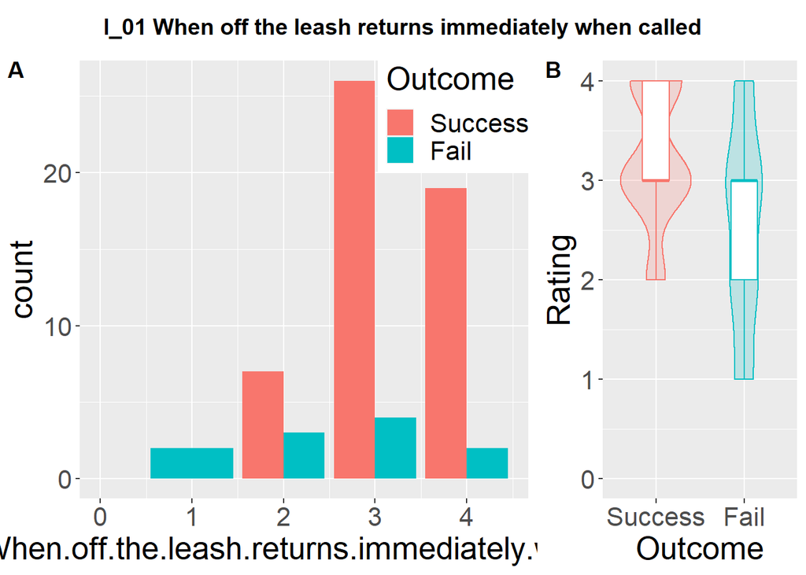

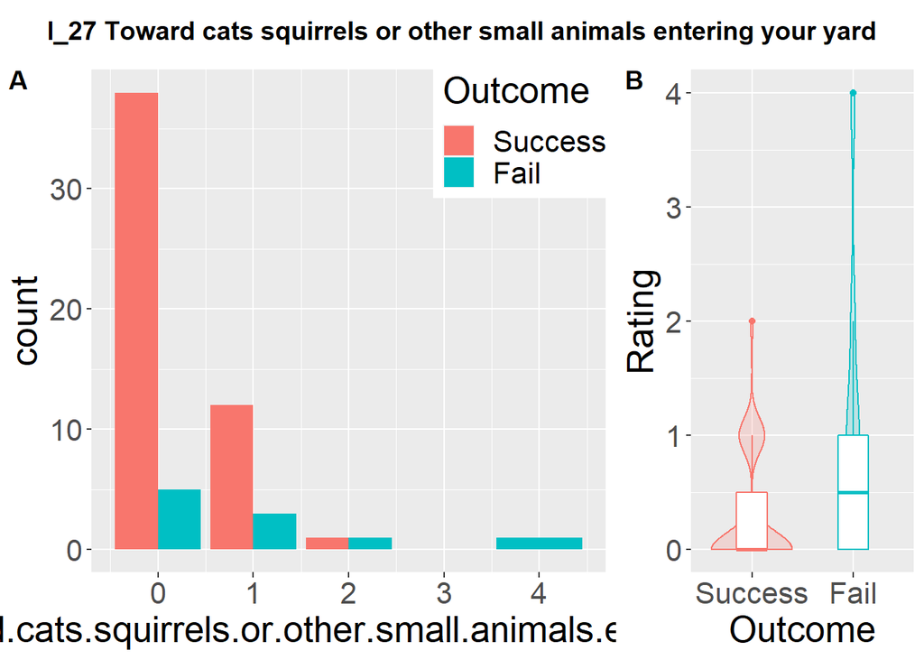

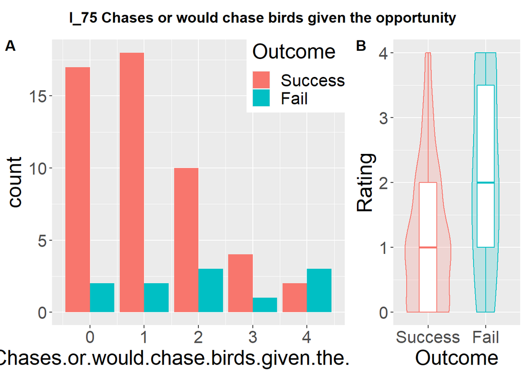

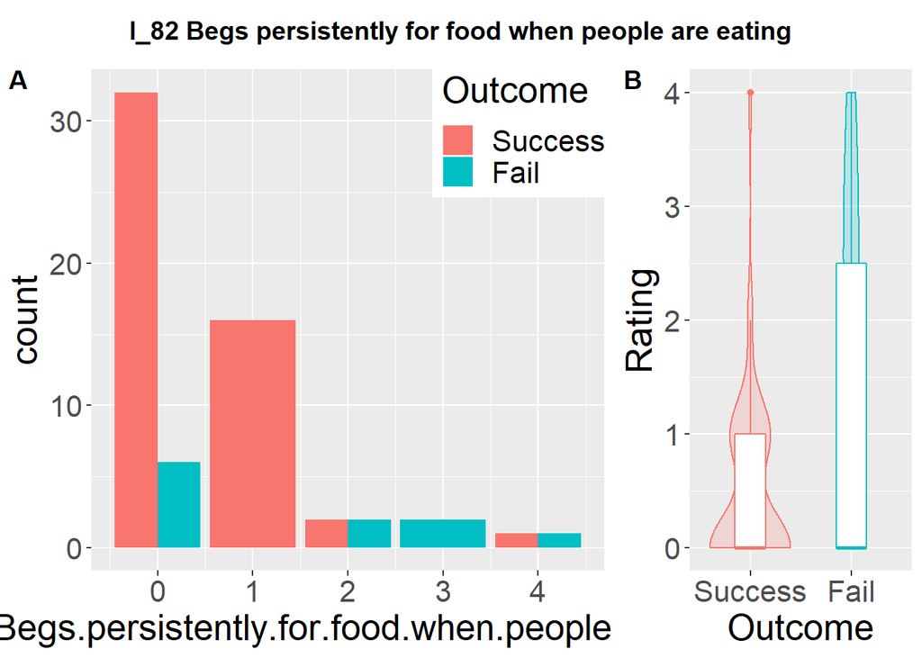

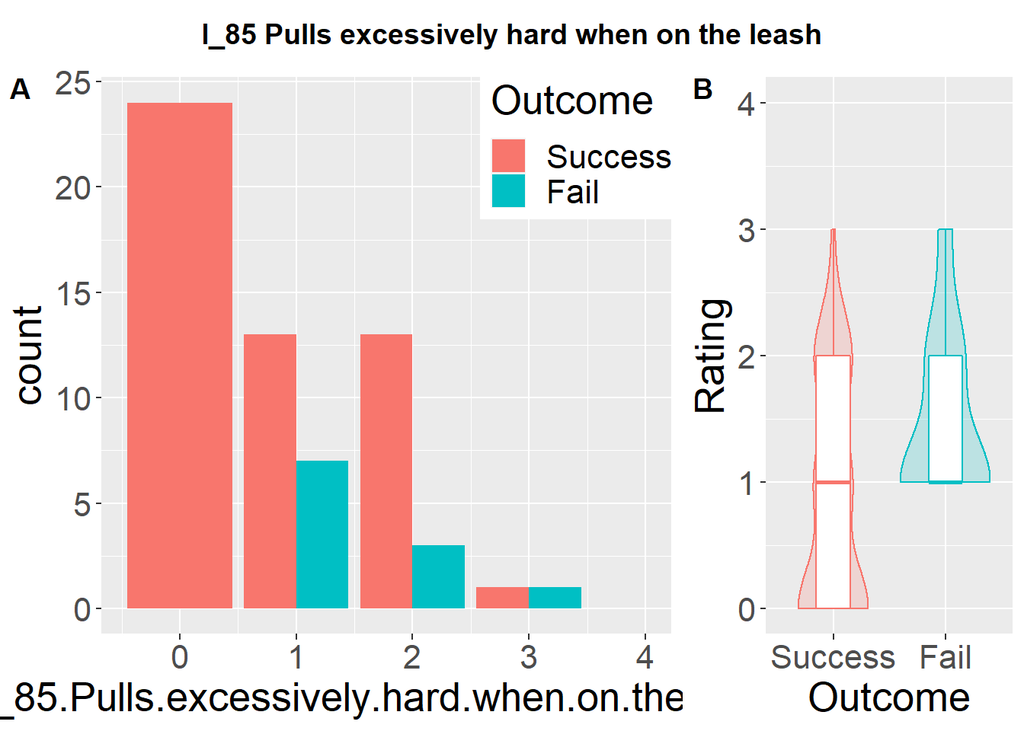

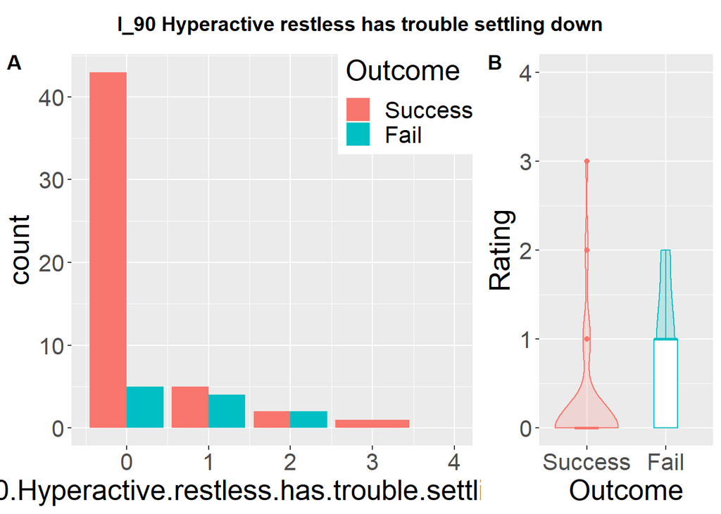

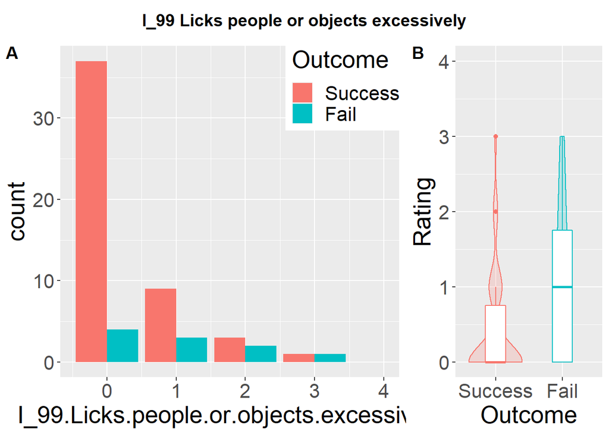

```
## Image saved at results/prq/F_02-Stranger-directed-aggression.png
```

```
## Image saved at results/prq/F_06-Nonsocial-fear.png
```

```
## Image saved at results/prq/F_08-Dog-directed-fear.png
```

```
## Image saved at results/prq/F_10-Separation-related-behaviour.png
```

```
## Image saved at results/prq/F_11-Excitability.png
```

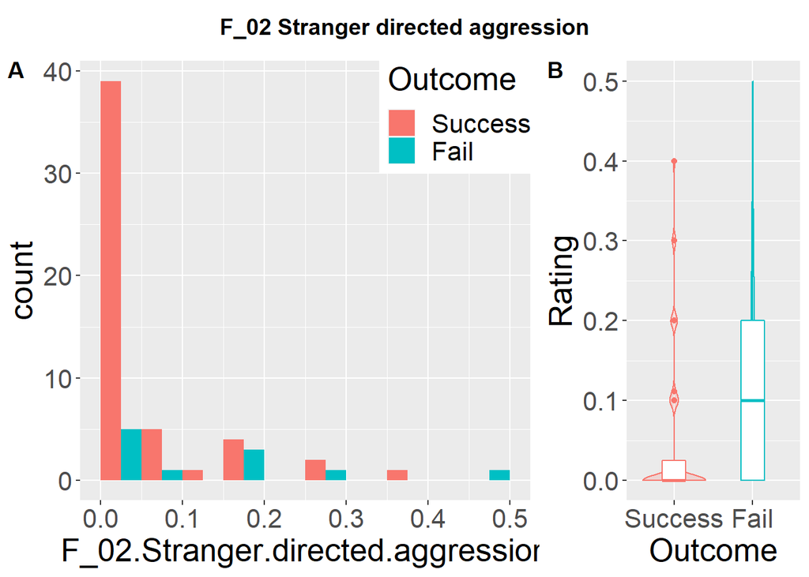

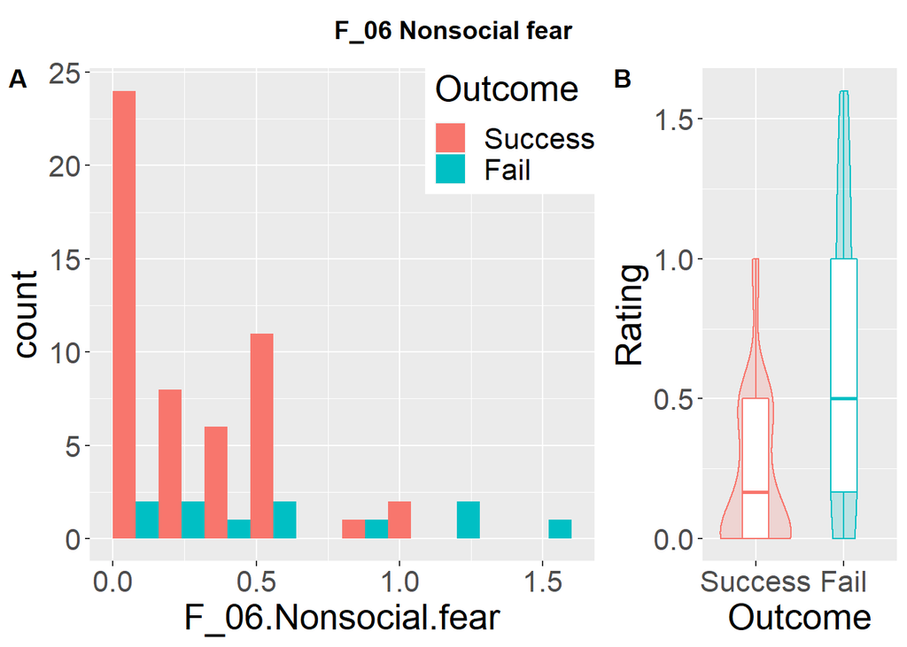

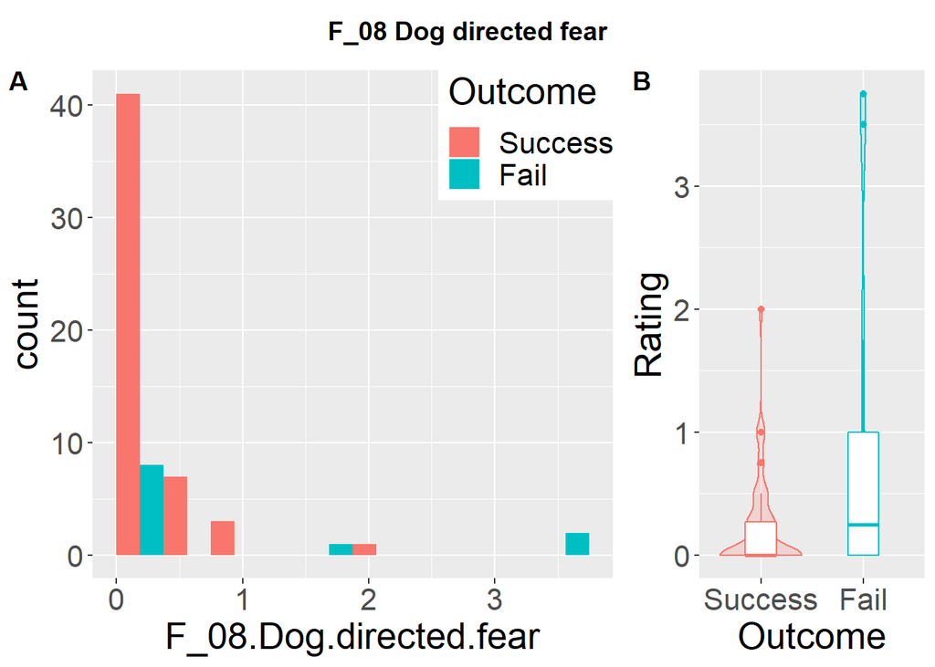

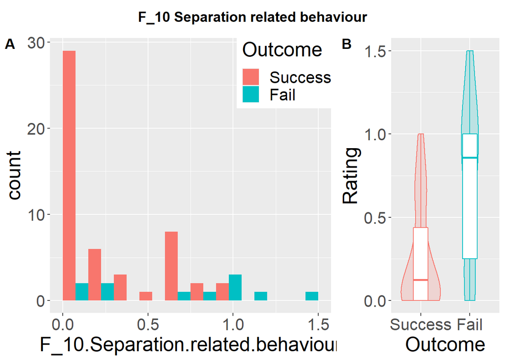

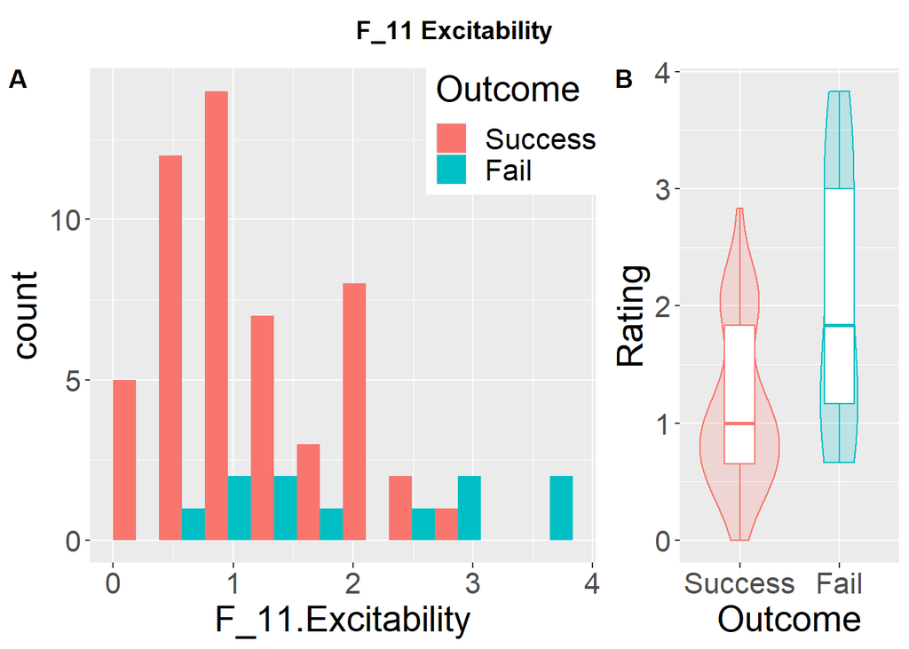

# 3 Multivariate Model

## 3.1 Multicollinearity

Calculate Variance Inflation Factor (VIF) to avoid multicollinearity. The glm models were built on the reduced feature sets and exclude any sample containing NAs. VIF larger than 5 or 10 is large and indicate a high level of multicollinearity.

The resulting multivariate logistic regression models are NOT looking good, p_values are all roughly 1. Mainly because they have small sample size (examples with NAs were removed). VIF values indicate a high degree of multicollinearity.

```
## VIF reduced
```

```
##
## Call:
## glm(formula = Outcome ~ ., family = binomial(link = logit), data = data_reduced,
##     na.action = na.exclude)
##
## Deviance Residuals:
##        Min          1Q      Median          3Q         Max
## -5.580e-05  -2.100e-08  -2.100e-08  -2.100e-08   5.864e-05
##
## Coefficients:
##                                                                       Estimate
## (Intercept)                                                            -380.37
## I_01.When.off.the.leash.returns.immediately.when.called                 -33.80
## I_27.Toward.cats.squirrels.or.other.small.animals.entering.your.yard     13.69
## I_75.Chases.or.would.chase.birds.given.the.opportunity                   82.17
## I_82.Begs.persistently.for.food.when.people.are.eating                   97.14
## I_85.Pulls.excessively.hard.when.on.the.leash                            15.97
## I_90.Hyperactive.restless.has.trouble.settling.down                     -91.67
## I_99.Licks.people.or.objects.excessively                                 56.48
## F_02.Stranger.directed.aggression                                      -319.22
## F_06.Nonsocial.fear                                                     124.32
## F_08.Dog.directed.fear                                                 -120.88
## F_10.Separation.related.behaviour                                       175.00
## F_11.Excitability                                                        49.80
##                                                                      Std. Error
## (Intercept)                                                           191217.65
## I_01.When.off.the.leash.returns.immediately.when.called                44465.63
## I_27.Toward.cats.squirrels.or.other.small.animals.entering.your.yard   36687.47
## I_75.Chases.or.would.chase.birds.given.the.opportunity                 29519.91
## I_82.Begs.persistently.for.food.when.people.are.eating                 49960.16
## I_85.Pulls.excessively.hard.when.on.the.leash                          15342.63
## I_90.Hyperactive.restless.has.trouble.settling.down                    51614.19
## I_99.Licks.people.or.objects.excessively                               25995.41
## F_02.Stranger.directed.aggression                                     158183.78
## F_06.Nonsocial.fear                                                    75214.25
## F_08.Dog.directed.fear                                                 47575.50
## F_10.Separation.related.behaviour                                      78518.72
## F_11.Excitability                                                      36845.94
##                                                                      z value
## (Intercept)                                                           -0.002
```

[output cut: 20 more lines]

```
## I_99.Licks.people.or.objects.excessively                                0.998
## F_02.Stranger.directed.aggression                                       0.998
## F_06.Nonsocial.fear                                                     0.999
## F_08.Dog.directed.fear                                                  0.998
## F_10.Separation.related.behaviour                                       0.998
## F_11.Excitability                                                       0.999
##
## (Dispersion parameter for binomial family taken to be 1)
##
##     Null deviance: 5.0063e+01  on 57  degrees of freedom
## Residual deviance: 1.5849e-08  on 45  degrees of freedom
##   (5 observations deleted due to missingness)
## AIC: 26
##
## Number of Fisher Scoring iterations: 25
```

```
## dataframe saved to  results/prq/multicollinearity.csv
```

```
##              I_01.When.off.the.leash.returns.immediately.when.called
##                                                            20.380913
## I_27.Toward.cats.squirrels.or.other.small.animals.entering.your.yard
##                                                            10.864771
##               I_75.Chases.or.would.chase.birds.given.the.opportunity
##                                                            27.487025
##               I_82.Begs.persistently.for.food.when.people.are.eating
##                                                            64.789317
##                        I_85.Pulls.excessively.hard.when.on.the.leash
##                                                             4.168593
##                  I_90.Hyperactive.restless.has.trouble.settling.down
##                                                            45.967984
##                             I_99.Licks.people.or.objects.excessively
##                                                             5.705442
##                                    F_02.Stranger.directed.aggression
##                                                             3.008470
##                                                  F_06.Nonsocial.fear
##                                                            18.955514
##                                               F_08.Dog.directed.fear
##                                                             8.144066
##                                    F_10.Separation.related.behaviour
##                                                            16.350214
##                                                    F_11.Excitability
##                                                            21.472998
```

```
## dataframe saved to  results/prq/VIF.csv
```

## 3.2 Preprocessing: Normalization + Imputation + PCA

PCA was performed using the entire reduced feature set. The “recipes” package was used to perform preprocessing (missing value imputation + normalization + PCA). [link](https://recipes.tidymodels.org/reference/step_pca.html), [Recipes documentation](https://cran.r-project.org/web/packages/recipes/recipes.pdf), [Example Recipes](https://www.rebeccabarter.com/blog/2019-06-06_pre_processing/)

## 3.3 Recursive Feature Elimination (RFE) + Multivariate Logistic Regression (LR)

Feature selection was performed using the caret packages rfe function. Logistic Regression was used to model the dataset and Leave One Subject Out Cross Validation was employed to validate the results. [Caret RFE](https://search.r-project.org/CRAN/refmans/caret/html/rfe.html), [Caret RFE Control](https://search.r-project.org/CRAN/refmans/caret/html/rfeControl.html), [Examples using RFE with Recipes](http://topepo.github.io/caret/recursive-feature-elimination.html#rferecipes) [Example RFE + RF as predictor](https://towardsdatascience.com/effective-feature-selection-recursive-feature-elimination-using-r-148ff998e4f7), [RFE + ROC as metric](https://stackoverflow.com/questions/18242692/r-package-caret-rfe-function-how-to-customize-metric-to-use-auc).

```
##  [1] "I_01.When.off.the.leash.returns.immediately.when.called"
##  [2] "I_27.Toward.cats.squirrels.or.other.small.animals.entering.your.yard"
##  [3] "I_75.Chases.or.would.chase.birds.given.the.opportunity"
##  [4] "I_82.Begs.persistently.for.food.when.people.are.eating"
##  [5] "I_85.Pulls.excessively.hard.when.on.the.leash"
##  [6] "I_90.Hyperactive.restless.has.trouble.settling.down"
##  [7] "I_99.Licks.people.or.objects.excessively"
##  [8] "F_02.Stranger.directed.aggression"
##  [9] "F_06.Nonsocial.fear"
## [10] "F_08.Dog.directed.fear"
## [11] "F_10.Separation.related.behaviour"
## [12] "F_11.Excitability"
## [13] "Outcome"
```

```
## predicting second class: Fail Success
```

```
##
## Recursive feature selection
##
## Outer resampling method: Cross-Validated (63 fold)
##
## Resampling performance over subset size:
##
##  Variables AUC Precision Recall F AUCSD PrecisionSD RecallSD FSD Num_Resamples
##          1 NaN    0.5714 0.3636 1    NA      0.5345   0.5045   0            63
##          2 NaN    0.4444 0.3636 1    NA      0.5270   0.5045   0            63
##          3 NaN    0.4286 0.2727 1    NA      0.5345   0.4671   0            63
##          4 NaN    0.5714 0.3636 1    NA      0.5345   0.5045   0            63
##          5 NaN    0.4286 0.2727 1    NA      0.5345   0.4671   0            63
##          6 NaN    0.4286 0.2727 1    NA      0.5345   0.4671   0            63
##          7 NaN    0.4286 0.2727 1    NA      0.5345   0.4671   0            63
##          8 NaN    0.4286 0.2727 1    NA      0.5345   0.4671   0            63
##          9 NaN    0.4286 0.2727 1    NA      0.5345   0.4671   0            63
##         10 NaN    0.4286 0.2727 1    NA      0.5345   0.4671   0            63
##  Selected
##         *
##
##
##
##
##
##
##
##
##
##
## The top 1 variables (out of 1):
##    PC01
```

```
##
## Call:
## glm(formula = Class ~ ., family = "binomial", data = tmp)
##
## Deviance Residuals:
##     Min       1Q   Median       3Q      Max
## -2.3068   0.2355   0.3159   0.4634   1.3166
##
## Coefficients:
##             Estimate Std. Error z value Pr(>|z|)
## (Intercept)   2.0555     0.4674   4.397  1.1e-05 ***
## PC01          0.8025     0.2425   3.310 0.000934 ***
## ---
## Signif. codes:  0 '***' 0.001 '**' 0.01 '*' 0.05 '.' 0.1 ' ' 1
##
## (Dispersion parameter for binomial family taken to be 1)
##
##     Null deviance: 58.352  on 62  degrees of freedom
## Residual deviance: 39.333  on 61  degrees of freedom
## AIC: 43.333
##
## Number of Fisher Scoring iterations: 5
```

Model fitness with deviance analysis.

```
##
## deviance difference:  19.01901
```

```
##
## df difference:  1
```

```
##
## level of significance:  1.294227e-05
```

```
##
## the model is a good fit:  TRUE
```

Performance metrics ROC and PR curves.

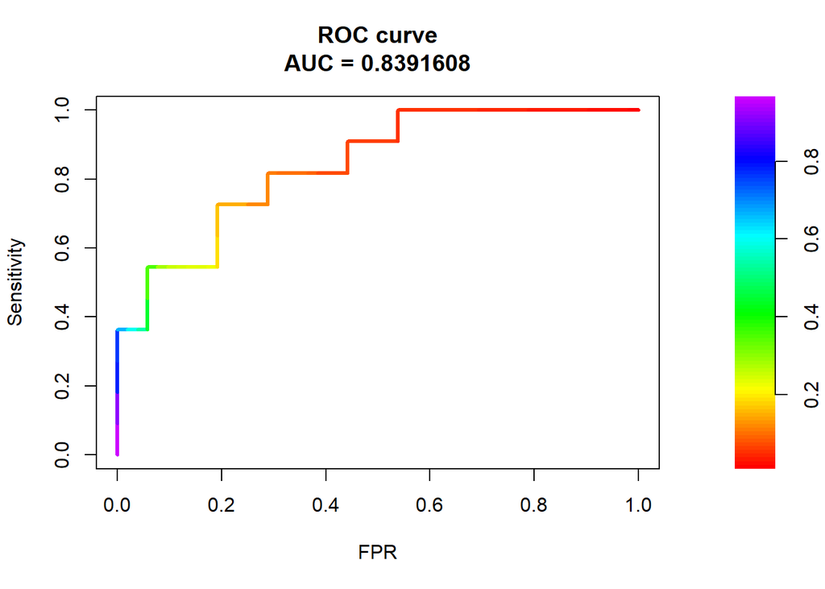

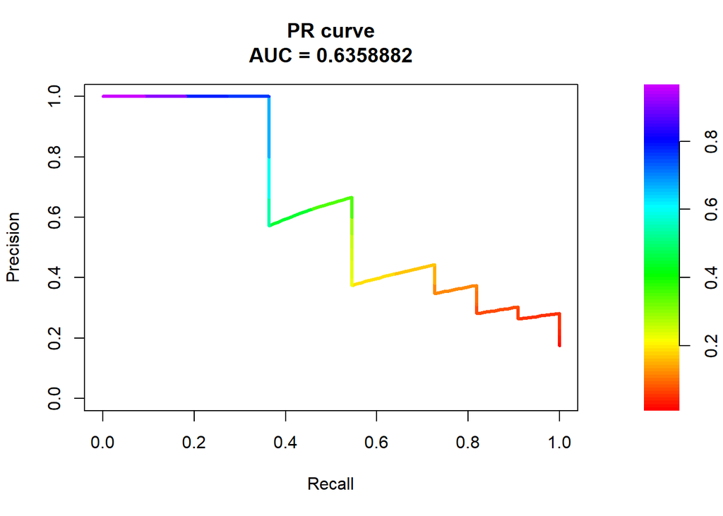

```
## Confusion Matrix and Statistics
##
##           Reference
## Prediction Fail Success
##    Fail       4       3
##    Success    7      49
##
##                Accuracy : 0.8413
##                  95% CI : (0.7274, 0.9212)
##     No Information Rate : 0.8254
##     P-Value [Acc > NIR] : 0.4483
##
##                   Kappa : 0.3571
##
##  Mcnemar's Test P-Value : 0.3428
##
##             Sensitivity : 0.36364
##             Specificity : 0.94231
##          Pos Pred Value : 0.57143
##          Neg Pred Value : 0.87500
##              Prevalence : 0.17460
##          Detection Rate : 0.06349
##    Detection Prevalence : 0.11111
##       Balanced Accuracy : 0.65297
##
##        'Positive' Class : Fail
##
```

```
##          Accuracy   ROC    PR Precision Recall Sensitivity Specificity    F1
## Accuracy    0.841 0.839 0.636     0.571  0.364       0.364       0.942 0.444
##          Balanced.Accuracy
## Accuracy             0.653
```

```
## [1] "Probability predicted by the LR using PRQ data vs true Outcome"
```

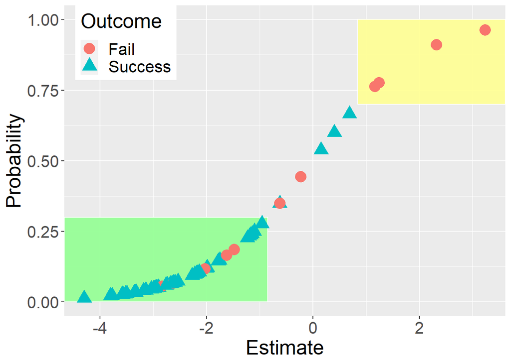

```
## Image saved at results/prq/logit-outcome.png
```

```
## [1] "Probability predicted by the LR using PRQ data vs true Status"
```

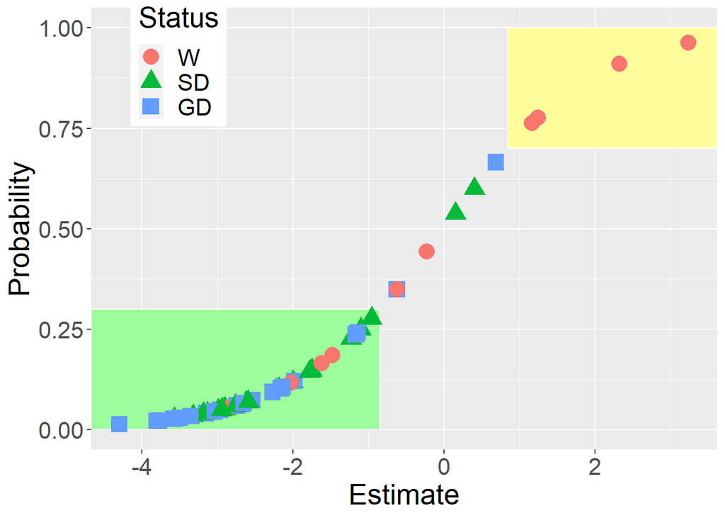

```
## Image saved at results/prq/logit-status.png
```

```
## [1] "Estimate and Probabilities per training outcome status"
```

```
## # A tibble: 3 × 2
##   Status   Mean
##   <fct>   <dbl>
## 1 W      -0.314
## 2 SD     -2.21
## 3 GD     -2.65
```

```
## # A tibble: 3 × 2
##   Status  Mean
##   <fct>  <dbl>
## 1 W      0.436
## 2 SD     0.138
## 3 GD     0.102
```

```
## Predicted probability < 0.3  -> Green flag
```

```
## [1] "Dogs flagged green are likely to SUCCEED, true outcome count and status proportion:"
```

```
##
##    Fail Success
##       5      48
```

```
##
##          W         SD         GD
## 0.09433962 0.45283019 0.45283019
```

```
## Predicted probability > 0.7 -> Yellow flag
```

[output not shown]

```
##
##    Fail Success
##       4       0
```

```
##
##  W SD GD
##  1  0  0
```

```
## 0.3  < Predicted probability < 0.7 -> no flags
```

```
##
##  W SD GD
##  2  2  2
```

## 3.4 Interpretation

```
## [1] "Results from the model created with the reduced feature set"
```

```
##              Estimate Std. Error  z value     Pr(>|z|)       OR    2.5 %
## (Intercept) 2.0554625  0.4674377 4.397298 0.0000109607 7.810450 3.461294
## PC01        0.8025444  0.2424733 3.309826 0.0009335405 2.231211 1.481145
##                97.5 %
## (Intercept) 22.635376
## PC01         3.896559
```

```
## dataframe saved to  results/prq/rfe-lr.csv
```

## 3.5 Feature Importance

### 3.5.1 Explained Variance

[output not shown]

### 3.5.2 Coefficient Loadings

Analysis of the principal component loadings that were used in the best Multivariate Logistic Regression Model.

The 5 highest loading values in PC1 come from the variables “F_11 Excitability” “F_08 Dog directed fear” “F_06 Nonsocial fear” “F_10 Separation related behaviour” “I_27 Toward cats squirrels or other small animals entering your yard” This indicates that this principal component places most variation in these variables.

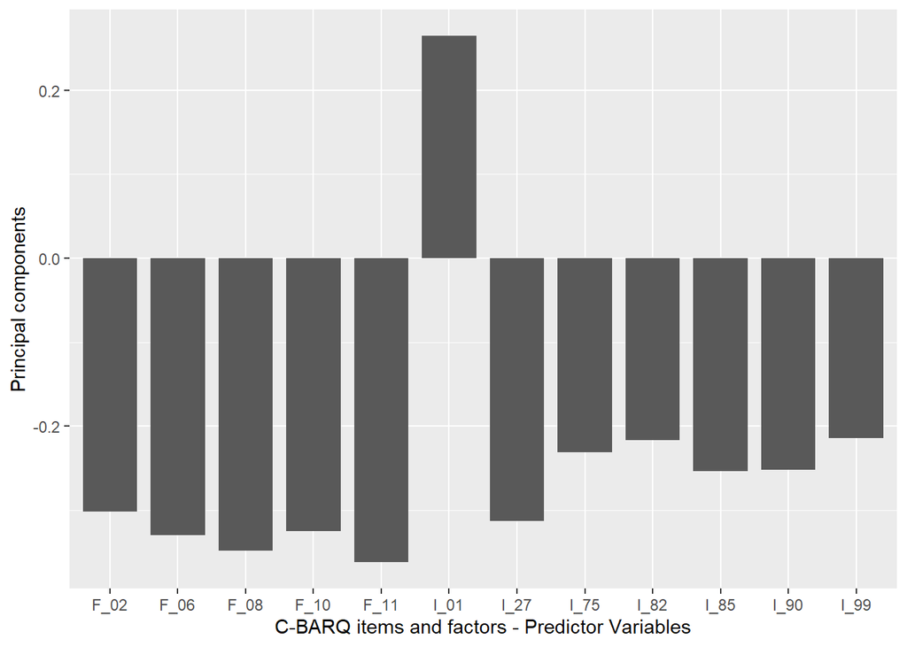

```
## Image saved at results/prq/pc-loading.png
```

```
## dataframe saved to  results/prq/pc-loading.csv
```

```
##                                                                   terms
## 1                                                     F_11.Excitability
## 2                                                F_08.Dog.directed.fear
## 3                                                   F_06.Nonsocial.fear
## 4                                     F_10.Separation.related.behaviour
## 5  I_27.Toward.cats.squirrels.or.other.small.animals.entering.your.yard
## 6                                     F_02.Stranger.directed.aggression
## 7               I_01.When.off.the.leash.returns.immediately.when.called
## 8                         I_85.Pulls.excessively.hard.when.on.the.leash
## 9                   I_90.Hyperactive.restless.has.trouble.settling.down
## 10               I_75.Chases.or.would.chase.birds.given.the.opportunity
## 11               I_82.Begs.persistently.for.food.when.people.are.eating
## 12                             I_99.Licks.people.or.objects.excessively
##         value
## 1  -0.3622558
## 2  -0.3481587
## 3  -0.3299666
## 4  -0.3246462
## 5  -0.3132483
## 6  -0.3014240
## 7   0.2645882
## 8  -0.2539598
## 9  -0.2516585
## 10 -0.2312900
## 11 -0.2168448
## 12 -0.2143621
```

# 4 Conclusion